# 第4回 線形回帰の評価プロトコルを実装し、結果を解釈する

写真の5色だけで、銀河までの距離はどこまで分かるか

# 導入

## データは、集めなくても手に入る

① データの宝庫●○○

- 研究で集めたデータの多くは公開され、誰でも解析できる
- 最終レポートでは、自分が解析したいデータを、自分で見つける
- 今日は、データの宝庫をいくつかのぞいてみる

## オミクス：生命のデータの宝庫

① データの宝庫●●○

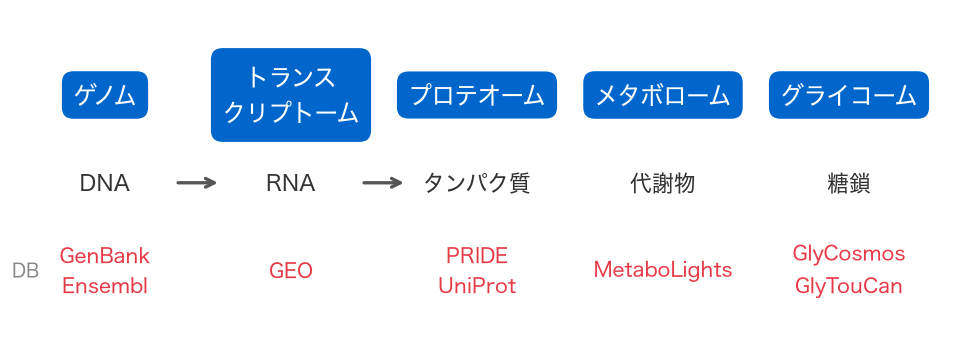

- 遺伝子・RNA・タンパク質・代謝物・糖鎖を、まるごと測ったデータ
- それぞれの層に、公開のデータベース（DB）がある

## がんやアルツハイマー病の研究にも

① データの宝庫●●●

- がん：TCGAは、多くの種類のがんのゲノムや遺伝子の働きを公開
- アルツハイマー病：ADNIは、脳画像や血液の検査値を長く追ったデータ
- 申請してから使うデータもある。使う前に、条件を確かめる

## 宇宙：望遠鏡が撮った膨大なデータ

② 宇宙と身近なデータ●○○

[figure not shown]

画像：© Ménard & Shtarkman（SDSS・Planckのデータ）

- 空を広く写して調べる観測（SDSS）、恒星の位置と動き（Gaia）
- ハッブルやジェイムズ・ウェッブ宇宙望遠鏡の観測データも公開（MAST）
- 撮りためたデータを解析して見つける。いま重要視されている使い方

## 身近なデータも

② 宇宙と身近なデータ●●○

- 気象（気象庁）、人口や経済の統計（e-Stat）
- スポーツの成績、音楽、ゲーム。好きなものにもデータがある

## データを探す

② 宇宙と身近なデータ●●●

- データの置き場（Zenodo・Dryad・Kaggle）にも、面白いデータが次々に
- 探すなら：Google Dataset Search

## データに合わせて組み立てる

③ 今日のデータ●○○

- 分野が変われば、データの形も、くせも違う
- 同じ道具を、そのデータに合わせて組み立て直す
- それが、データサイエンスの醍醐味

## 第3回は民泊、今日は宇宙

③ 今日のデータ●●○

- 第3回は東京の民泊の料金、今日は空の銀河
- データの形もくせも違う。でも、式を作って測り、確かめる手順は同じ

## 今日は宇宙のデータベース

③ 今日のデータ●●●

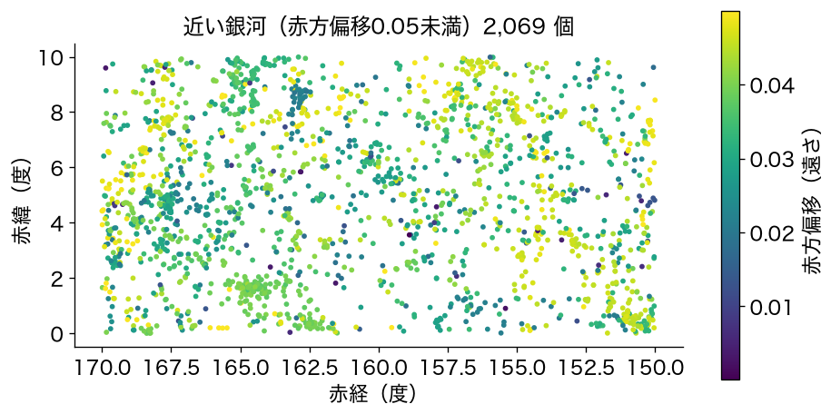

- SDSS（スローン・デジタル・スカイ・サーベイ）の、空の一角の近い銀河
- 同じ色（同じ遠さ）の銀河が、ところどころに集まっている
- 銀河の色だけで、その銀河までの距離が分かるか

## 銀河の地図には距離が要る

④ 場面●○○○○○○

- 天文学者は、宇宙の中で銀河がどう並んでいるか、地図を作っている
- 地図を作るには、一つひとつの銀河までの距離が要る

## 距離は分光で測れる

④ 場面●●○○○○○

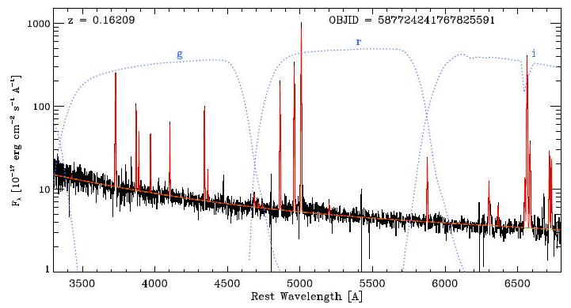

画像：C. Cardamone（SDSSのデータ）, CC BY-SA 3.0, Wikimedia Commons

- 銀河の光を虹のように分ける（分光）と、距離が正確に分かる
- ただし、分光は1個ずつ時間がかかる
- 写真なら一度に何百万個も撮れる。分かるのは5色の明るさだけ

## 写真の5色

④ 場面●●●○○○○

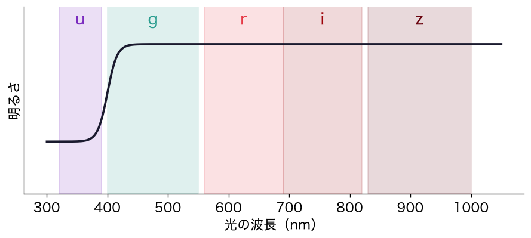

- u・g・r・i・zの5つのフィルターで、それぞれの色の明るさを測る

## 光の線が、赤い側へずれる

④ 場面●●●●○○○

[figure not shown]

画像：G. Wiora, CC BY-SA 3.0, Wikimedia Commons

- 左は太陽の光、右は遠い銀河の集まりの光を、虹のように分けたもの
- 黒い線（吸収線）が、そろって赤い側へずれる

## 遠い銀河ほど、光が赤い側にずれる

④ 場面●●●●●○○

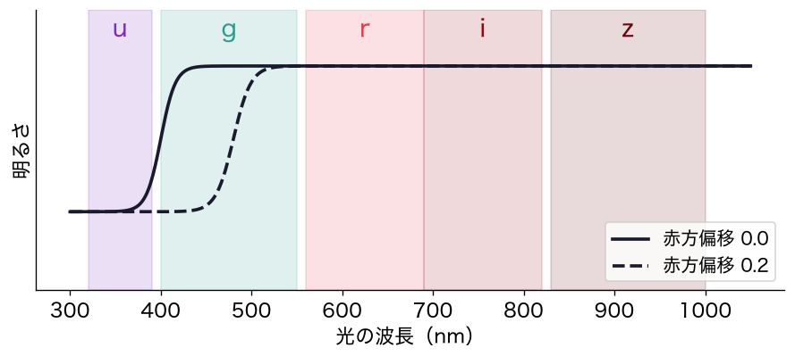

- 明るさの段差が、遠い銀河では右（赤い側）にずれる
- ずれた割合を、赤方偏移（redshift）と呼ぶ

## 赤方偏移から距離へ

④ 場面●●●●●●○

$$\text{距離} \approx \text{赤方偏移} \times 140\text{億光年}$$

- 近い銀河なら、赤方偏移に約140億光年を掛けると、およその距離
- 赤方偏移0.1なら、およそ14億光年先

## 決めたいこと

④ 場面●●●●●●●

- 分光できた銀河を手がかりに、写真の5色から赤方偏移を当てる式を作りたい
- 天文学で実際に使われている、測光的赤方偏移の考え方

## 手元のデータ

⑤ 手元のデータ●○

- SDSS（スローン・デジタル・スカイ・サーベイ）の、空の一角の銀河14,983個
- 1行が1個の銀河。列は5色の明るさ（等級）と、分光で測った赤方偏移
- 等級は、数が大きいほど暗い

## データをのぞく

⑤ 手元のデータ●●

|  | u | g | r | i | z | 赤方偏移 |
| --- | --- | --- | --- | --- | --- | --- |
| 0 | 19.172 | 17.764 | 17.097 | 16.698 | 16.368 | 0.03267 |
| 1 | 19.991 | 18.264 | 17.094 | 16.623 | 16.312 | 0.18533 |
| 2 | 19.475 | 17.437 | 16.488 | 16.015 | 15.662 | 0.08912 |
| 3 | 18.027 | 16.442 | 15.685 | 15.276 | 14.957 | 0.03275 |
| 4 | 19.126 | 17.124 | 16.225 | 15.802 | 15.485 | 0.08735 |

- 今日は「分光できたのは1,000個だけ」として、1,000個を抜き出して使う

## 第3回で残したこと

⑥ 今日の問い●○○

- 第3回は、MAEで式を測り、整えるたびに比べた
- でも、そのMAEは、分け方1通りで測った数だった
- 式の係数が何を言っているかも、まだ読んでいない

## 最後に出す答え

⑥ 今日の問い●●○

- 写真の5色から、赤方偏移をどれくらいの外れで当てられるか
- 5色の式の係数が、何を言っているか

## 今日の問い

⑥ 今日の問い●●●

写真の5色だけで、銀河までの距離はどこまで分かるか？

## もう1つのねらい：リストにためる

⑦ もう1つのねらい●

- `for`でくり返した結果を、リストにためて並べられるようになる
- 1回分を返す短い関数を作り、くり返しは関数の外の`for`で書く

# 今日の一周

## 結果だけで一度通す

⑧ 今日の一周●○○○○○○

- まず、今日の解析を、結果だけで一度通して見る
- コードはあとで。どんな結論になるかを先に知っておく

## 一周①：5色で当てる

⑧ 今日の一周●●○○○○○

- 赤方偏移は平均0.0187外れる。距離に直すと約2.6億光年

## 一周②：分け方で揺れる

⑧ 今日の一周●●●○○○○

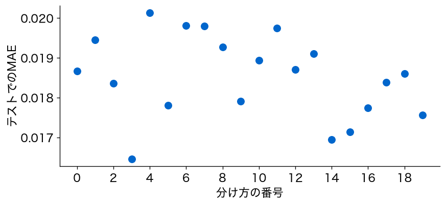

- 分け方を20通りに変えると、MAEは0.0165〜0.0201と揺れる

## 一周③：uは要る？

⑧ 今日の一周●●●●○○○

- 交差検証で比べると、5色の式（0.0191）がuを外した式（0.0223）に勝つ

## 一周④：rの係数がマイナス？

⑧ 今日の一周●●●●●○○

```
r だけの式   0.033
5色の式     -0.214
```

- rだけで当てると、暗いほど遠い（プラス）
- 5色を一緒に入れると、暗いほど近い（マイナス）？

## 一周⑤：えっ、予測は同じなのに

⑧ 今日の一周●●●●●●○

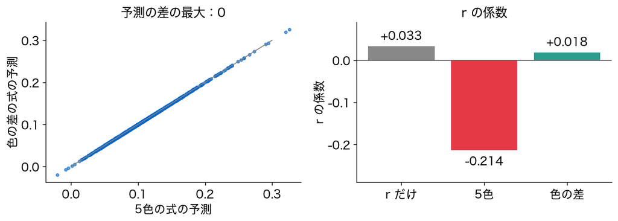

- 色の差で式を作り直すと、予測は1つも変わらない（左）
- それなのに、rの係数はプラスに戻る（右）

## 一周は4つの段

⑧ 今日の一周●●●●●●●

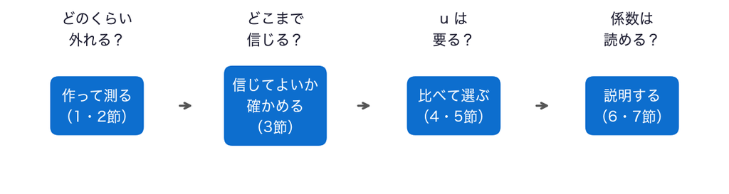

- このあと、4つの段の中身を、1つずつ開けていく

## 問いとやること①②

⑨ 問いとやること●○

- 作って測る：どのくらい外れる？ → 5色で式を作り、テストの銀河で外れを測る（1・2節）
- 確かめる：その数字は、どこまで信じてよい？ → 分け方を20通りに変えて、MAEの揺れを見る（3節）

## 問いとやること③④

⑨ 問いとやること●●

- 比べて選ぶ：uは要る？ → 同じ分け方どうしで比べ、交差検証で比べ直す（4・5節）
- 説明する：係数は読める？ → rの係数を読み、相関を見て、色の差で式を作り直す（6・7節）

## 今日の進め方

10 今日の進め方●

- 段ごとに、スライドで聞く → ノートで実行して答える
- 段の終わりの「ノートへ」で、予想を書き、1か所を替えて実行し、予想と比べる
- 予想は外れてかまわない

# 0. 準備

## まずは道具とデータ

- 0節は、ノートで1節と続けて実行する
- 道具を呼び出す → 表を読み込む → 1,000個を抜き出す

## お手本：1,000個を抜き出す

0節 ① 1,000個を抜き出す●○

```python
df = raw.sample(1000, random_state=0).reset_index(drop=True)
bands = ['u', 'g', 'r', 'i', 'z']
print(len(df), '個')
print(df['赤方偏移'].describe().round(3))
print((df['赤方偏移'] > 0.2).sum(), '個は赤方偏移が0.2より大きい')
```

```
1000 個
count    1000.000
mean        0.107
std         0.052
min         0.004
25%         0.071
50%         0.099
75%         0.137
max         0.343
58 個は赤方偏移が0.2より大きい
```

- `sample`：行をくじで選ぶ。`random_state`を決めると、毎回同じ1,000個

## 赤方偏移の中央値は0.099

0節 ① 1,000個を抜き出す●●

- 中央値の銀河までは、およそ14億光年
- 赤方偏移が0.2より大きい遠い銀河は、58個だけ

# 1. 5色で式を作る

## 段1：作って測る

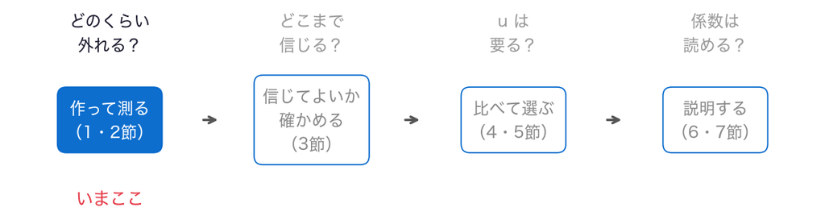

- 問い：写真の5色で、赤方偏移はどのくらい外れずに当たるか
- まず、第2回と同じ手順で、分けて式を作る

## 式の形

1節 ① 式を作る●○

$$\hat{y}_i = b_0 + b_1 x_{i1} + b_2 x_{i2} + \cdots + b_5 x_{i5}$$

- $x_{i1}, \dots, x_{i5}$は$i$番目の銀河の5色の等級
- $b_1, \dots, b_5$が係数、$b_0$が切片。$\hat{y}_i$が赤方偏移の予測

## お手本：分けて式を作る

1節 ① 式を作る●●

```python
tr, te = train_test_split(df, test_size=0.25, random_state=0)
m = LinearRegression().fit(tr[bands], tr['赤方偏移'])
pred = m.predict(te[bands])
print(len(tr), len(te))
```

```
750 250
```

- 訓練750個、テスト250個。テストは、式を作るのに使っていない銀河

# 2. どのくらい外れる？

## 外れを測る：MAE

2節 ① MAE●○○○

$$\text{MAE} = \frac{1}{n}\sum_{i=1}^{n} \lvert y_i - \hat{y}_i \rvert$$

- $y_i$は実際の赤方偏移、$\hat{y}_i$はその予測
- 外れの大きさを、全部の銀河で平均する（第3回のおさらい）

## 式は二乗で作り、MAEで測る

2節 ① MAE●●○○

- 係数は、外れの二乗の和が最小になるように決めた（第2回の最小二乗法）
- 成績はMAEで測る。作る基準と測る物差しは、別々に選んでよい
- MAEなら「赤方偏移が平均でいくつ外れるか」を、そのまま言える

## お手本：外れを測る

2節 ① MAE●●●○

```python
err = np.abs(te['赤方偏移'] - pred)          # 外れの大きさ
print(round(err.mean(), 4))                  # MAE
print(round(err.mean() * 140, 1), '億光年')   # 距離に直す
print(round(m.score(te[bands], te['赤方偏移']), 2))  # R²
```

```
0.0187
2.6 億光年
0.74
```

- 赤方偏移で0.0187、距離で約2.6億光年の外れ。R²は0.74

## 14億光年先を、2.6億光年の外れで

2節 ① MAE●●●●

- 写真の5色だけで、14億光年ほど先の銀河までの距離が分かる
- 分光しなくても、銀河の地図の下書きが描ける

## お手本：予測と実際を描く

2節 ② 散布図●○

```python
plt.scatter(te['赤方偏移'], pred, s=12)
plt.plot([0, 0.35], [0, 0.35], color='gray')
plt.xlabel('実際の赤方偏移')
plt.ylabel('予測')
plt.show()
```

[output not shown]

## 線から離れた点がある

2節 ② 散布図●●

## 重要：MAEは平均の外れ

2節 ③ 大外れを見る●○○○

MAEは「平均でどれだけ外れるか」。大外れがあっても、平均にならされて見えない。

## お手本：大きく外れた銀河

2節 ③ 大外れを見る●●○○

```python
big = err >= 0.05
print(big.sum(), '個')
print(round(err.max(), 3), round(err.max() * 140, 1), '億光年')
print((te[big]['赤方偏移'] > 0.2).sum(), '個は0.2より大きい')
te[big][bands + ['赤方偏移']]
```

```
13 個
0.155 21.7 億光年
6 個は0.2より大きい
```

- `err >= 0.05`でTrue/Falseの並びを作り、Trueの行だけを残す（第1回）

## 13個が0.05以上外れた

2節 ③ 大外れを見る●●●○

- 250個のうち13個。いちばん大きな外れは0.155（21.7億光年）
- 13個のうち6個は、赤方偏移が0.2より大きい遠い銀河
- 遠い銀河は、手元の1,000個に58個しかない

## 重要：大外れは1個ずつ見る

2節 ③ 大外れを見る●●●●

大外れは、平均の数だけで済ませず、1個ずつ見る。どんな銀河が外れたかで、式の弱点が分かる。

## ここまでで分かったこと

2節 ④ 分かったこと●

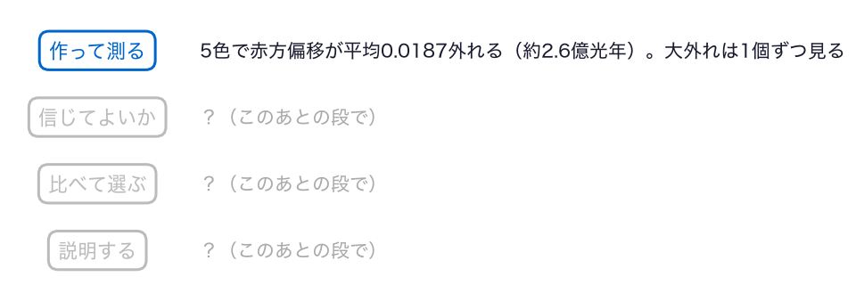

- まだ分からない：0.0187という数を、どこまで信じてよいか

## ノートへ：0〜2節

2節 ⑤ ノートへ●

- 0〜2節のセルを上から実行し、スライドと同じ数が出るか確かめる
- やってみよう：大きく外れる銀河があることを、地図を作るときにどう扱うか

動画の人は、ここで一時停止。

# 3. その数字、どこまで信じる？

## 段2：信じてよいか確かめる

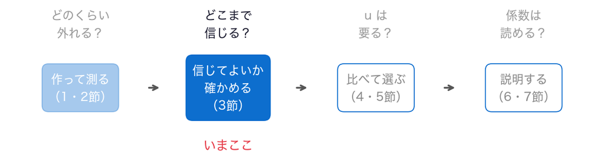

- 問い：その数字は、どこまで信じてよい？
- 2節の0.0187は、`random_state=0`の1通りの分け方で出した数

## 大外れの扱い方

3節 ① 前の段から●

- 大外れの半分近くは、遠い銀河。式は遠い銀河を近めに当てている
- 地図に注意書きを付けるか、分光で測り直す候補にする
- MAEだけでなく、大外れの数も一緒に伝える

## おさらい：for文と関数

3節 ② 1回分の関数●○○

```python
def double(x):
    return x * 2

for s in range(3):
    print(double(s))   # 0, 2, 4 と順に表示される
```

- `def`で関数を作り、`return`の後ろが戻り値
- `for`は、並びの中身を1つずつ入れて、字下げした行をくり返す

## お手本：1回分のMAEを返す関数

3節 ② 1回分の関数●●○

```python
def one_mae(df, cols, s):
    tr_s, te_s = train_test_split(df, test_size=0.25, random_state=s)
    m_s = LinearRegression().fit(tr_s[cols], tr_s['赤方偏移'])
    pred_s = m_s.predict(te_s[cols])
    return np.abs(te_s['赤方偏移'] - pred_s).mean()

print(round(one_mae(df, bands, 0), 4))
```

```
0.0187
```

- 中の4行は、1・2節を並べただけ。`s`を変えると分け方が変わる

## 関数は入力と出力で読む

3節 ② 1回分の関数●●●

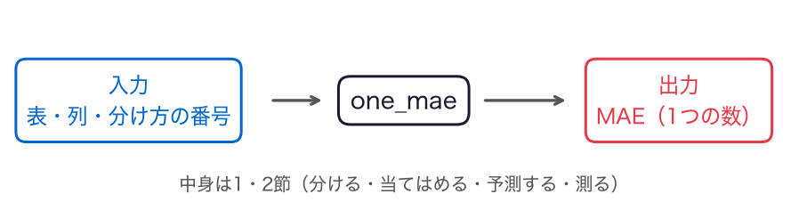

- `s = 0`では0.0187で、2節と同じ数

## 新しい書き方：リストにためる

3節 ③ リストにためる●○○

```python
x = []           # 空のリスト
x.append(5)      # x は [5]
x.append(7)      # x は [5, 7]
```

- くり返しの結果を、1つずつためておく入れ物がリスト
- `append(値)`で、後ろに1つ足す
- NumPyの`np.append`は、足すたびに配列を作り直すので、くり返しには使わない

## お手本：分け方を20通り

3節 ③ リストにためる●●○

```python
maes = []
for s in range(20):
    maes.append(one_mae(df, bands, s))
print(round(min(maes), 4), round(max(maes), 4))
print(round(np.mean(maes), 4))
```

```
0.0165 0.0201
0.0185
```

- 関数は1回分だけ、くり返しは外の`for`が受け持つ

## 1回ごとに、後ろに1つ足す

3節 ③ リストにためる●●●

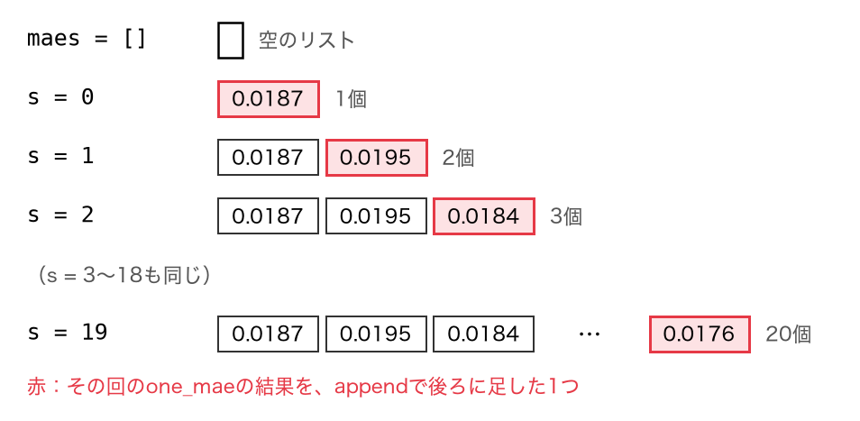

- 20回まわると、`maes`に20個のMAEがたまる

## お手本：点で描く

3節 ④ 数の揺れ●○○

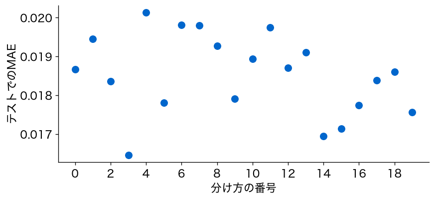

```python
plt.plot(maes, 'o')
plt.xlabel('分け方の番号')
plt.ylabel('テストでのMAE')
plt.show()
```

## 0.0165〜0.0201

3節 ④ 数の揺れ●●○

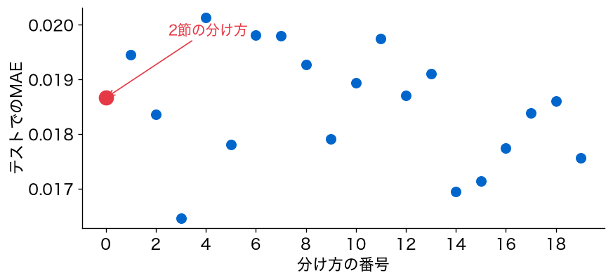

- 2節の0.0187は、20通りのうちの1つにすぎない

## 評価まで変わる

3節 ④ 数の揺れ●●●

- 同じ式、同じ1,000個なのに、どの250個がテストに入るかで上下する
- 0.0165なら「よく当たる」、0.0201なら「まあまあ」
- 1回の分け方の数は、その分け方の運を含んでいる

## 重要概念：リストにためる

3節 ⑤ 重要概念●

くり返しの結果は、空のリストを作り、`for`の中で`append`して1つずつためる。ためておくと、20個を並べて、最小・最大・平均を出せる。

## TODO①：銀河の数を替える

3節 ⑥ 銀河の数●

```python
# TODO: 1000 を 300 に替えて実行する
df_n = raw.sample(1000, random_state=0).reset_index(drop=True)
maes_n = []
for s in range(20):
    maes_n.append(one_mae(df_n, bands, s))
print(round(max(maes_n) - min(maes_n), 4))
```

- 予想：銀河を300個に減らすと、揺れの幅（最大−最小）はどうなる？
- 予想を書いてから、`1000`を`300`に替えて実行する

## ここまでで分かったこと

3節 ⑦ 分かったこと●

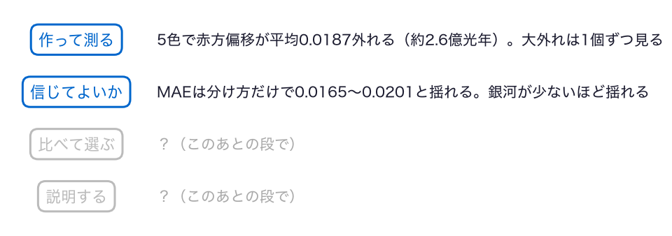

- まだ分からない：揺れる数どうしで、どうやって式を比べるか

## ノートへ：3節

3節 ⑧ ノートへ●

- 3節のセルを上から実行し、スライドと同じ数が出るか確かめる
- TODO①：予想を書く → `1000`を`300`に替えて実行 → 予想と比べる

動画の人は、ここで一時停止。

## 答え合わせ：TODO①

3節 ⑨ 答え合わせ●○

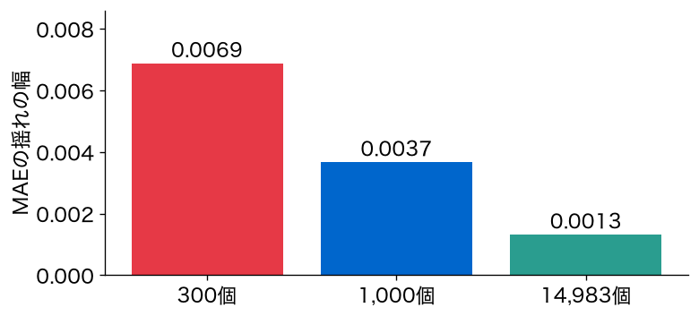

- 300個では幅0.0069、1,000個の2倍近く。全部の14,983個では0.0013
- 銀河が少ないほど、どの銀河がテストに入るかの運が効く

## 重要：データが少ないほど揺れる

3節 ⑨ 答え合わせ●●

データが少ないほど、1回の分け方の数は揺れる。少ないデータの評価ほど、1回では信じない。

# 4. uを外すと？

## 段3：比べて選ぶ

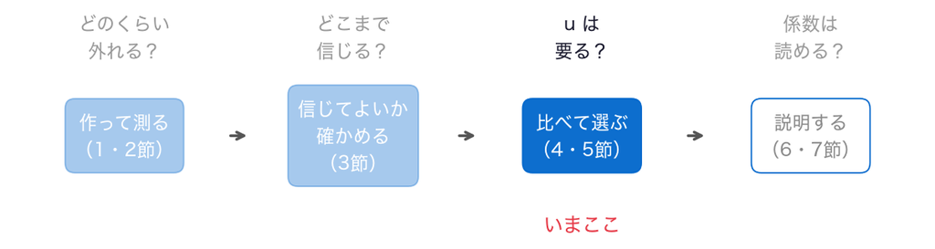

- 問い：5色のうち、uは要る？
- MAEは分け方だけで揺れた。揺れる数どうしで、どう比べるか

## uは測りにくい色

4節 ① uを外す●○○

- uは紫外の光。5色の中でいちばん暗く、測りにくい
- 外したほうが、かえって当たるかもしれない

## お手本：uを外した式も20通り

4節 ① uを外す●●○

```python
no_u = ['g', 'r', 'i', 'z']
maes_no_u = []
for s in range(20):
    maes_no_u.append(one_mae(df, no_u, s))
print(round(np.mean(maes_no_u), 4))
```

```
0.0216
```

- `one_mae`に渡す列の組を替えるだけで、別の式を測れる

## 0.0185と0.0216、比べてよい？

4節 ① uを外す●●●

- 平均では、uを外した式（0.0216）のほうが悪い
- でも、MAEは分け方だけで0.0165〜0.0201と揺れる
- この差は、揺れの中に埋もれていないか

## お手本：勝ち負けを数える

4節 ② 同じ分け方で比べる●○○

```python
wins = 0
for s in range(20):
    if maes[s] < maes_no_u[s]:
        wins = wins + 1
print(wins, '回は5色の式が勝った')
```

```
20 回は5色の式が勝った
```

- `maes[s]`は、リストの`s`番目（0から数える）。番号が同じなら、テストの250個も同じ

## お手本：2本の線で描く

4節 ② 同じ分け方で比べる●●○

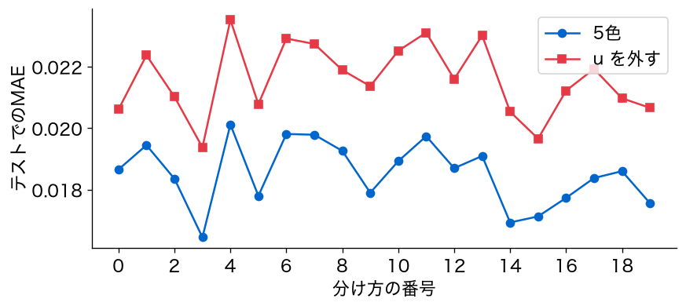

```python
plt.plot(maes, 'o-', label='5色')
plt.plot(maes_no_u, 's-', label='u を外す')
plt.xlabel('分け方の番号')
plt.ylabel('テストでのMAE')
plt.legend()
plt.show()
```

## 一緒に上下し、いつも四角が上

4節 ② 同じ分け方で比べる●●●

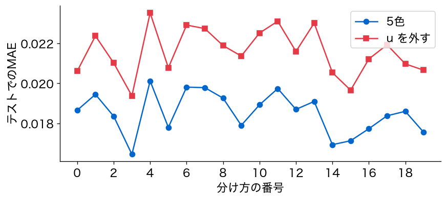

- 同じ銀河で測った2つのMAEなら、差は式の違いだけから生まれる

## 別々の分け方で比べると？

4節 ③ 別々の分け方●○

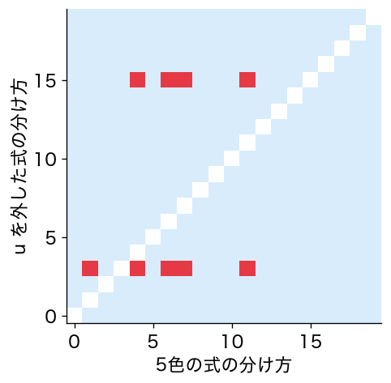

- 赤：uを外した式のほうが良く見えた組。380組のうち9組

## 悪い式が良く見えることがある

4節 ③ 別々の分け方●●

- 当てやすい銀河がテストに入った分け方と比べると、悪い式が良く見える
- 式を比べるときは、同じ分け方どうしで並べる

# 5. 全部の銀河を1度ずつテストに

## 20回の分け直しの偏り

5節 ① 数え方の偏り●○

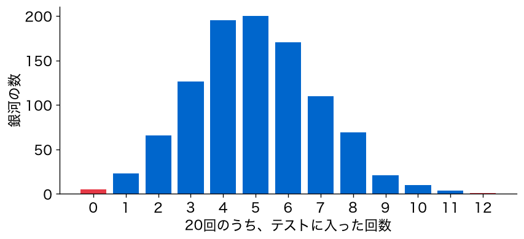

- 20回で1度もテストに入らない銀河が5個、12回入った銀河が1個

## どの銀河も1度ずつテストに

5節 ① 数え方の偏り●●

- 20回の平均は、何度も入った銀河ほど重く数える
- どの銀河も、ちょうど1度ずつテストに入るように分けられないか

## 5つの組を順にテストに

5節 ② 交差検証●○

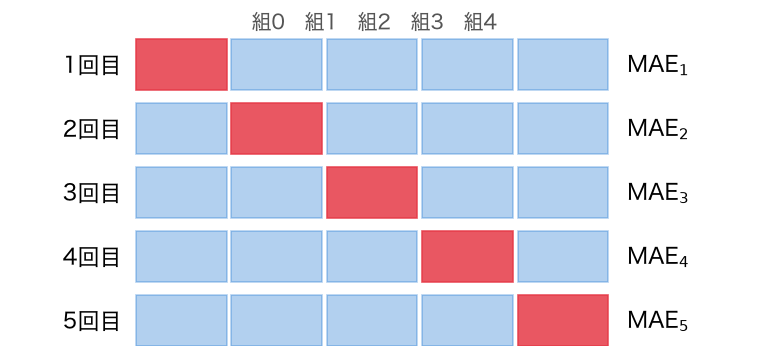

- 5つの組に分け、1つずつテストにして、5回MAEを測る

## 交差検証を式で

5節 ② 交差検証●●

$$\text{CV} = \frac{1}{K}\sum_{k=1}^{K} \text{MAE}_k$$

- $K$は組の数（今日は5）、$\text{MAE}_k$は$k$番目の組をテストにしたMAE
- このやり方を、$K$分割交差検証（cross-validation, CV）と呼ぶ
- MAEでなく、ほかの外れの物差しを平均してもよい

## お手本：組の番号を振る

5節 ③ 組を作る●○

```python
df['組'] = df.index % 5
print(df['組'].value_counts())
```

```
組
0    200
1    200
2    200
3    200
4    200
```

- `%`は割った余り。行の番号0〜999に、0, 1, 2, 3, 4, 0, 1, …と振る
- `df`はくじで抜き出したので、並びはもともとばらばら

## お手本：交差検証の関数

5節 ③ 組を作る●●

```python
def cv_mae(cols):
    maes_k = []
    for k in range(5):
        tr_k = df[df['組'] != k]      # 組k以外で訓練
        te_k = df[df['組'] == k]      # 組kでテスト
        m_k = LinearRegression().fit(tr_k[cols], tr_k['赤方偏移'])
        pred_k = m_k.predict(te_k[cols])
        maes_k.append(np.abs(te_k['赤方偏移'] - pred_k).mean())
    return maes_k
```

- `one_mae`と比べて、変わったのは分け方だけ
- 組`k`でない行で訓練、組`k`の行でテスト。第1回の、条件で絞る書き方

## お手本：2つの式を交差検証で

5節 ④ 交差検証で比べる●○○

```python
cv5 = cv_mae(bands)
cv4 = cv_mae(no_u)
print(np.round(cv5, 4), round(np.mean(cv5), 4))
print(np.round(cv4, 4), round(np.mean(cv4), 4))
print(round(np.mean(cv5) * 140, 1), '億光年')   # 5色の式を距離に直す
```

```
[0.0204 0.018  0.0209 0.0186 0.0179] 0.0191
[0.0223 0.0205 0.024  0.0225 0.0224] 0.0223
2.7 億光年
```

- 5色の式は0.0191（約2.7億光年）、uを外すと0.0223

## お手本：組ごとに描く

5節 ④ 交差検証で比べる●●○

```python
plt.plot(cv5, 'o-', label='5色')
plt.plot(cv4, 's-', label='u を外す')
plt.xlabel('テストにした組')
plt.ylabel('MAE')
plt.legend()
plt.show()
```

[output not shown]

## 5つの組すべてで5色が勝つ

5節 ④ 交差検証で比べる●●●

- uは、暗くて測りにくい色でも、赤方偏移を当てる手がかりになっている

## 重要概念：交差検証

5節 ⑤ 重要概念●

1回の分け方の数は揺れる。だから、全部の行を1度ずつテストに回し、外れ（今日はMAE）を平均する。2つの式は、同じ組どうしで比べる。

## TODO②：外す色を替える

5節 ⑥ 外す色●

```python
# TODO: 別の色を1つ外した並びに替えて実行する
cols_x = ['g', 'r', 'i', 'z']
print(round(np.mean(cv_mae(cols_x)), 4))
```

- 予想：5色のうち、どの色を外すと、いちばん悪くなる？
- 予想を書いてから、並びを替えて実行する（gを外すなら`['u', 'r', 'i', 'z']`）

## ここまでで分かったこと

5節 ⑦ 分かったこと●

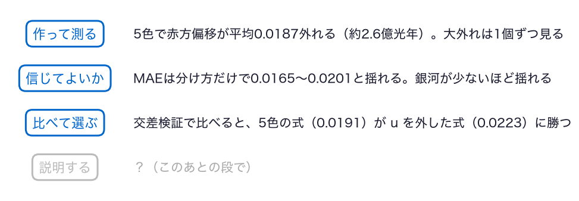

- まだ分からない：この式が何を言っているか

## ノートへ：4・5節

5節 ⑧ ノートへ●

- 4・5節のセルを上から実行し、スライドと同じ数が出るか確かめる
- TODO②：予想を書く → 外す色を替えて実行 → 予想と比べる

動画の人は、ここで一時停止。

## 答え合わせ：TODO②

5節 ⑨ 答え合わせ●○

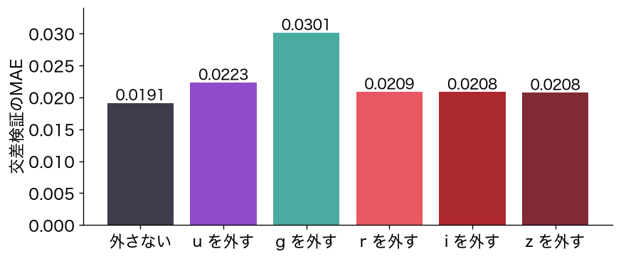

- gを外すと0.0301で、いちばん悪い。uを外すと0.0223

## r・i・zはどれを外しても同じ

5節 ⑨ 答え合わせ●●

- r・i・zは、どれを外しても約0.0208で、あまり変わらない
- 1つを外しても、残りの2色がほとんど同じことを知っている
- この3色の関係が、次の段の入り口

# 6. rの係数はなぜマイナス？

## 段4：説明する

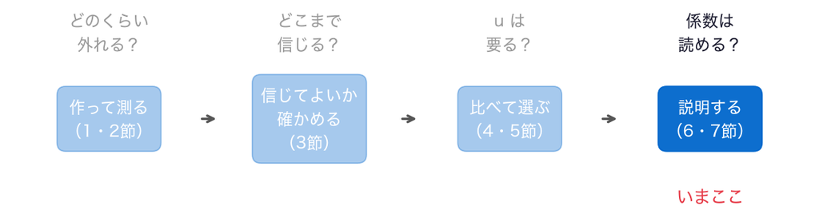

- 問い：この式の係数は、読める？
- 当たりの良い式が決まった。次は、式の係数を読む

## 係数の読み方

6節 ① 係数の読み方●

$$\hat{y}_i = b_0 + b_1 x_{i1} + \cdots + b_5 x_{i5}$$

- ほかの列を全部そのままにして、$x_{ij}$だけを1増やすと、予測は$b_j$だけ変わる
- 係数$b_j$は「ほかの列を同じにしたまま、その列を1増やしたときの変化」

## お手本：rだけの式と5色の式

6節 ② rの係数●○○

```python
m_r = LinearRegression().fit(df[['r']], df['赤方偏移'])
m_all = LinearRegression().fit(df[bands], df['赤方偏移'])
print(m_r.coef_.round(3))
print(pd.Series(m_all.coef_, index=bands).round(3))
```

```
[0.033]
u   -0.058
g    0.314
r   -0.214
i   -0.216
z    0.192
```

- `pd.Series(係数, index=列の名前)`で、係数に列の名前を付ける

## rだけなら、暗いほど遠い

6節 ② rの係数●●○

- rだけの式では、rの係数は+0.033
- rで1等暗い銀河は、赤方偏移が0.033大きい。直感どおり

## 5色なら、暗いほど近い？

6節 ② rの係数●●●

- 5色の式では、rの係数は−0.214
- 「ほかの4色を同じにしたまま、rだけ暗いと、近い」と読めてしまう
- 暗いほど近い、ということがあるのか

## お手本：5色どうしの相関

6節 ③ 相関を見る●○○

```python
print(df[bands].corr().round(3))
```

```
       u      g      r      i      z
u  1.000  0.916  0.758  0.688  0.620
g  0.916  1.000  0.943  0.904  0.859
r  0.758  0.943  1.000  0.988  0.974
i  0.688  0.904  0.988  1.000  0.993
z  0.620  0.859  0.974  0.993  1.000
```

- `corr()`は、列どうしの相関係数を表にする

## rで暗い銀河は、iでも暗い

6節 ③ 相関を見る●●○

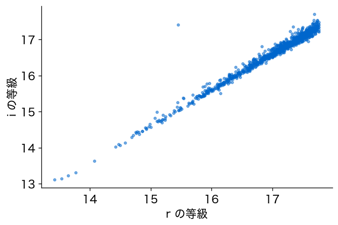

- rとiの相関は0.988、iとzは0.993。5色はほとんど同じことを言う

## ありえない比べ方

6節 ③ 相関を見る●●●

- 「ほかの4色を同じにしたまま、rだけ1等暗い」銀河は、まずない
- そんな銀河は、色がまったく違う銀河
- −0.214は、ありえない比べ方の答え

## お手本：分け方でrの係数は？

6節 ④ 係数の揺れ●○

```python
def r_coef(cols, s):
    tr_s, te_s = train_test_split(df, test_size=0.25, random_state=s)
    m_s = LinearRegression().fit(tr_s[cols], tr_s['赤方偏移'])
    return pd.Series(m_s.coef_, index=cols)['r']

coefs = []
for s in range(20):
    coefs.append(r_coef(bands, s))
print(round(min(coefs), 3), round(max(coefs), 3))
```

```
-0.235 -0.137
```

- `one_mae`と同じ形。最後の行だけ、MAEの代わりにrの係数を返す

## rの係数は−0.235〜−0.137

6節 ④ 係数の揺れ●●

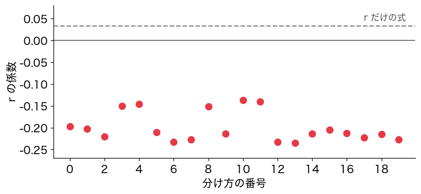

- rだけの式（点線、+0.033）と比べて、符号が逆で、大きさも分け方しだい
- 相関の強い列を一緒に入れると、係数が揺れる。多重共線性（multicollinearity）

## 重要：多重共線性

6節 ⑤ 多重共線性●

相関の強い列を一緒に入れると、予測は良くても、係数は揺れて読めない（多重共線性）。係数を読む前に、列どうしの相関を見る。

# 7. 係数を読める式にするには？

## 当たりを保ったまま読めないか

- 5色の式は、多重共線性で係数が読めない。でも、当たりは良い
- 当たりを保ったまま、係数を読める式に作り直せないか

## 天文学者は色の差を見る

7節 ① 色の差●○○

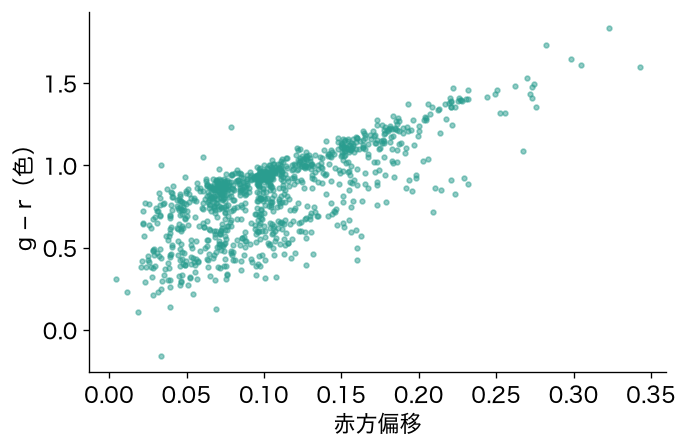

- g − rは、緑で見た明るさと赤で見た明るさの差。銀河の「色」
- 遠い銀河ほど、g − rが大きい（赤い）

## お手本：色の差の列を作る

7節 ① 色の差●●○

```python
df['u-g'] = df['u'] - df['g']
df['g-r'] = df['g'] - df['r']
df['r-i'] = df['r'] - df['i']
df['i-z'] = df['i'] - df['z']
colors = ['u-g', 'g-r', 'r-i', 'i-z', 'r']
print(df[colors].corr().round(2))
```

```
      u-g   g-r   r-i   i-z     r
u-g  1.00  0.79  0.61  0.64 -0.01
g-r  0.79  1.00  0.54  0.79  0.13
r-i  0.61  0.54  1.00  0.36  0.11
i-z  0.64  0.79  0.36  1.00 -0.04
r   -0.01  0.13  0.11 -0.04  1.00
```

## rと色の差は別のことを言う

7節 ① 色の差●●●

- rと色の差4本の相関は、どれも絶対値で0.13以下
- rは「全体の明るさ」、色の差は「色」

## お手本：色の差の式

7節 ② 色の差の式●○○○○

```python
m_c = LinearRegression().fit(df[colors], df['赤方偏移'])
diff = np.abs(m_c.predict(df[colors]) - m_all.predict(df[bands]))
print(round(diff.max(), 10))
coef_c = pd.Series(m_c.coef_, index=colors)
print(coef_c.round(3))
```

```
0.0
u-g   -0.058
g-r    0.256
r-i    0.024
i-z   -0.192
r      0.018
```

## 予測は1つも変わらない

7節 ② 色の差の式●●○○○

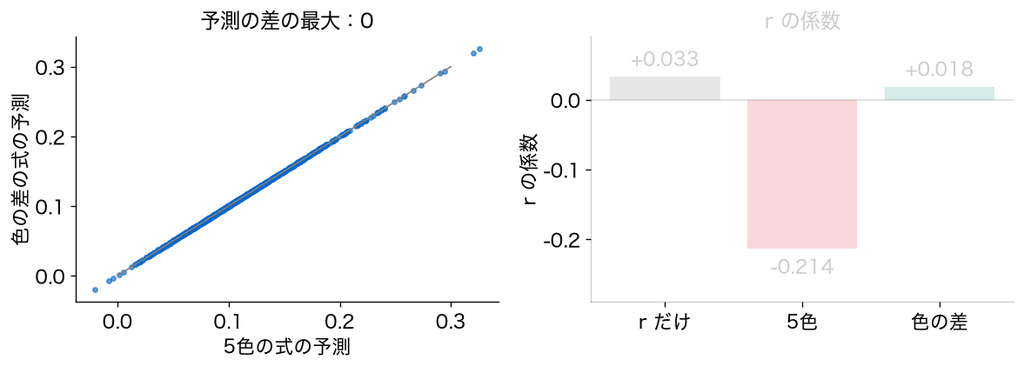

- 1,000個すべてで、2つの式の予測は同じ。点は一直線に並ぶ
- 色の差4本とrがあれば、5色の等級はすべて計算で戻せるから

## それなのにrの係数は+0.018

7節 ② 色の差の式●●●○○

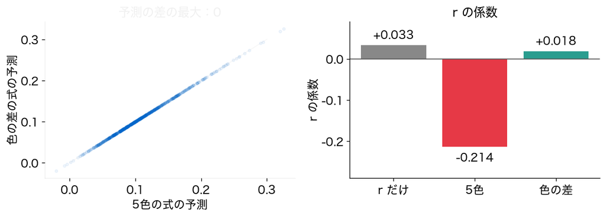

- 同じ予測をする式なのに、rの係数は−0.214から+0.018へ、符号まで変わる
- 同じ色の銀河がrで暗く見えるなら、遠いから。直感どおりに読める